# n-grams

## N-граммы

Пока что единицей измерения текста у нас были отдельные слова. Тем самым мы полностью игнорировали информацию о последовательности слов в тексте. По этой причине векторное представление документа еще называют «мешком слов» (bag of words), потому что мы рассматриваем набор слов, но не их порядок. Однако есть простой способ, принципиально не меняя наших инструментов измерения текста, инкорпорировать в них информацию о последовательности слов — *n-граммы*. Вместо одного слова возьмем в качестве единицы несколько стоящих подряд слов.

```r
library(tidyverse)
library(tidytext)
reviews <- read_csv("~/shared/minor2_2017/2-tm/lab02_tf_idf/reviews.csv")
reviews.bigrams = reviews %>%
  unnest_tokens(bigram, lem, token = "ngrams", n = 2)

reviews.bigrams %>%
  dplyr::count(bigram, sort = TRUE)
```

```
## # A tibble: 161,919 x 2
##    bigram                n
##    <chr>             <int>
##  1 в номер            2505
##  2 в отель            1683
##  3 этот отель         1582
##  4 в этот             1428
##  5 останавливаться в  1158
##  6 отель в             993
##  7 номер быть          753
##  8 в центр             714
##  9 вид на              670
## 10 очень понравиться   650
## # ... with 161,909 more rows
```

```r
reviews.bifiltered = reviews.bigrams %>%
  separate(bigram, c("word1", "word2"), sep = " ") %>%
  filter(!word1 %in% stopwords::stopwords("ru")) %>%
  filter(!word2 %in% stopwords::stopwords("ru"))

reviews.bifiltered %>%
  dplyr::select(word1, word2) %>%
  dplyr::count(word1, word2, sort = TRUE)
```

```
## # A tibble: 95,553 x 3
##    word1      word2            n
##    <chr>      <chr>        <int>
##  1 очень      понравиться    650
##  2 центр      город          602
##  3 отель      очень          533
##  4 невский    проспект       513
##  5 очень      хороший        488
##  6 очень      удобный        465
##  7 московский вокзал         425
##  8 хороший    отель          424
##  9 самый      центр          422
## 10 удобный    расположение   395
## # ... with 95,543 more rows
```

```r
reviews.bifiltered %>%
  filter(word2 == "центр") %>%
  count(word1, word2, sort=TRUE) %>%
  dplyr::select(word1, word2, n)
```

```
## # A tibble: 109 x 3
##    word1                 word2     n
##    <chr>                 <chr> <int>
##  1 самый                 центр   422
##  2 исторический          центр   106
##  3 торговый              центр    60
##  4 расположение          центр    22
##  5 спа                   центр    21
##  6 фитнес                центр    13
##  7 весь                  центр    11
##  8 тихий                 центр    10
##  9 отель                 центр     8
## 10 достопримечательность центр     7
## # ... with 99 more rows
```

```r
reviews.bifiltered %>%
  filter(word2 == "центр") %>%
  dplyr::count(rating, word1, sort=TRUE) %>%
  filter(rating>3)
```

```
## # A tibble: 125 x 3
##    rating word1            n
##     <int> <chr>        <int>
##  1      5 самый          282
##  2      4 самый          124
##  3      5 исторический    68
##  4      5 торговый        35
##  5      4 исторический    32
##  6      4 торговый        23
##  7      5 расположение    17
##  8      5 спа             16
##  9      5 тихий            8
## 10      5 фитнес           8
## # ... with 115 more rows
```

```r
reviews.bigrams = reviews.bifiltered %>%
  unite(bigram, word1, word2, sep = " ")
```

## Совместная встречаемость

Что если мы хотим посмотреть на то, как все слова связаны друг с другом? Для этого мы можем применить сетевой анализ к нашим биграмам. Представим наши слова в виде сети.

```r
library(igraph)
# выберем только часто встречающиеся биграммы и сделаем сеть
reviews.net = reviews.bifiltered %>%
  dplyr::select(word1, word2) %>%
  dplyr::count(word1, word2, sort = TRUE) %>%
  filter(n >= 50) %>%
  graph_from_data_frame()

reviews.net
```

```
## IGRAPH 76ea817 DN-- 200 258 --
## + attr: name (v/c), n (e/n)
## + edges from 76ea817 (vertex names):
##  [1] очень       ->понравиться  центр       ->город
##  [3] отель       ->очень        невский     ->проспект
##  [5] очень       ->хороший      очень       ->удобный
##  [7] московский  ->вокзал       хороший     ->отель
##  [9] самый       ->центр        удобный     ->расположение
## [11] отель       ->располагать  ванный      ->комната
## [13] шведский    ->стол         приветливый ->персонал
## [15] расположение->отель        высокий     ->уровень
## + ... omitted several edges
```

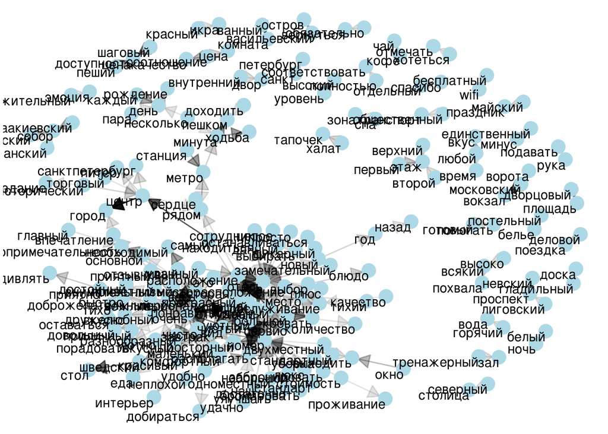

```r
# теперь можно визуализировать то, что получилось

library(ggraph)
set.seed(2018)

a <- grid::arrow(type = "closed", length = unit(.15, "inches"))

ggraph(reviews.net, layout = "fr") +
  geom_edge_link(aes(edge_alpha = n), show.legend = FALSE,
                 arrow = a, end_cap = circle(.07, 'inches')) +
  geom_node_point(color = "lightblue", size = 5) +
  geom_node_text(aes(label = name), vjust = 1, hjust = 1) +
  theme_void()
```

При помощи данной визуализации мы можем увидеть, как пары слов друг с другом связаны. Но более интеренсным для нас будет анализ того, как слова потенциально могут встречаться друг с другом в одном документе, даже если они не стоят рядом в предложении.

Для нашей следующей задачи мы должны немного изменить то, как представлены наши данные. Нам нужно сначала представить данные в широком формате. То есть, сделать из них матрицу. Затем мы считаем нужную нам метрику, которая покажет, насколько слова связаны друг с другом. В нашем случае мы будем использовать PMI снова. После того, как нужная метрика посчитана, мы можем снова представить наши данные в длинном формате для дальнейшего построения графа.

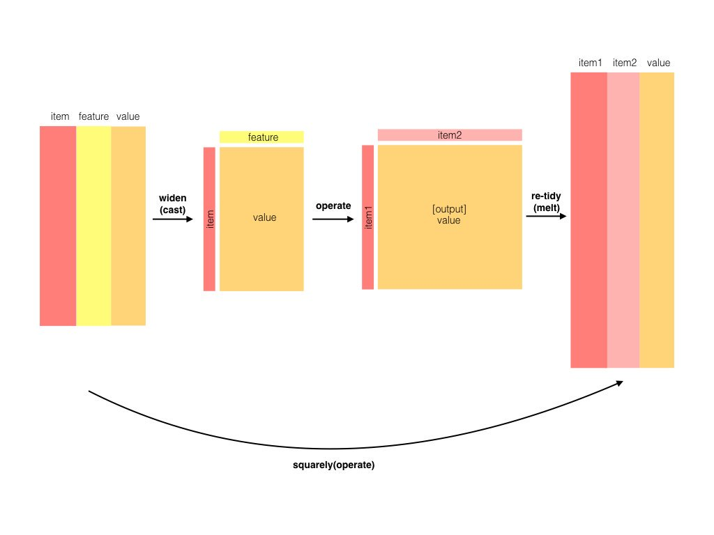

```r
library(widyr)
library(RCurl)
script <- getURL("https://raw.githubusercontent.com/voskresenskiy/widyr/master/R/pmi_changed.R", ssl.verifypeer = F)
eval(parse(text = script))
script <- getURL("https://raw.githubusercontent.com/paulponcet/lplyr/master/R/col_name.R", ssl.verifypeer = F)
eval(parse(text = script))
```

```r
reviews.tidy = reviews %>%
  dplyr::select(id, lem) %>%
  unnest_tokens(words, lem)

rustopwords <- data.frame(words=stopwords::stopwords("ru"), stringsAsFactors=FALSE)

reviews.tidy = reviews.tidy %>%
  anti_join(rustopwords)
word_pmi <- reviews.tidy %>%
  group_by(words) %>%
  filter(n() >= 50)

pmi_counts = pairwise_pmi(word_pmi, words, id, sort = T)
pmi_counts$pmi = ifelse(pmi_counts$pmi < 0, 0, pmi_counts$pmi)

pmi_counts %>%
  filter(item1 == "центр")
```

```
## # A tibble: 939 x 3
##    item1 item2           pmi
##    <chr> <chr>         <dbl>
##  1 центр торговый      1.47
##  2 центр город         0.914
##  3 центр галерея       0.913
##  4 центр исторический  0.900
##  5 центр казанский     0.895
##  6 центр самый         0.687
##  7 центр добираться    0.685
##  8 центр остановка     0.652
##  9 центр автобус       0.632
## 10 центр располагаться 0.632
## # ... with 929 more rows
```

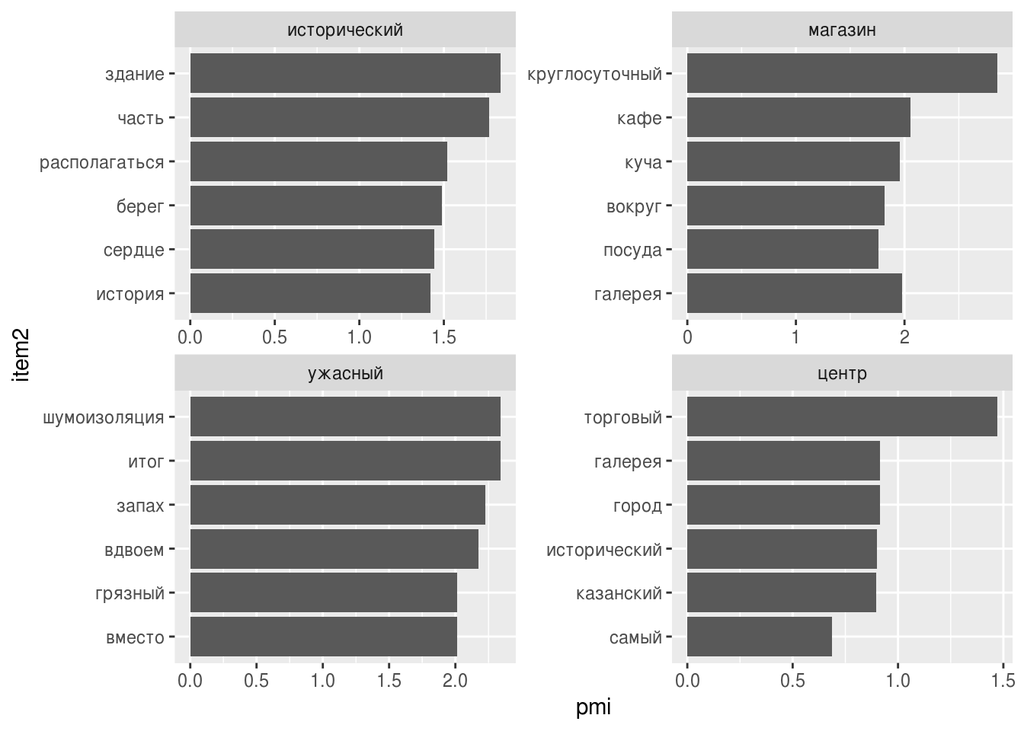

```r
pmi_counts %>%
  filter(item1 %in% c("центр", "магазин", "исторический", "ужасный")) %>%
  group_by(item1) %>%
  top_n(6) %>%
  ungroup() %>%
  mutate(item2 = reorder(item2, pmi)) %>%
  ggplot(aes(item2, pmi)) +
  geom_bar(stat = "identity") +
  facet_wrap(~ item1, scales = "free") +
  coord_flip()
```

Применим сетевые методы

```r
set.seed(2016)

pmi_graph = pmi_counts %>%
  filter(pmi > 2) %>%
  graph_from_data_frame()

kc <- walktrap.community(pmi_graph)
length(kc)
```

```
## [1] 104
```

```r
sizes(kc)
```

```
## Community sizes
##   1   2   3   4   5   6   7   8   9  10  11  12  13  14  15  16  17  18
##   7   6  15  27  19  14  12   5   5  67  32  10   7   5  23   9   6   9
##  19  20  21  22  23  24  25  26  27  28  29  30  31  32  33  34  35  36
##   6   6  10  21  18   8   6  10   7   4  15  10   7   6   4   5   4   5
##  37  38  39  40  41  42  43  44  45  46  47  48  49  50  51  52  53  54
##   4   5   5   6   4   4   6   3   5   3   7   4   3   3   4   5   4   5
##  55  56  57  58  59  60  61  62  63  64  65  66  67  68  69  70  71  72
##   5   3   3   3   3   5   3   2   2   2   2   2   2   2   2   2   2   2
##  73  74  75  76  77  78  79  80  81  82  83  84  85  86  87  88  89  90
##   2   2   2   2   2   3   2   3   2   4   4   3   3   3   3   3   3   2
##  91  92  93  94  95  96  97  98  99 100 101 102 103 104
##   2   2   2   2   2   2   2   2   2   2   2   2   2   2
```

```r
table <- cbind(kc$membership, kc$names)
table = as.data.frame(table)

filter(table, V1 == 5) %>% head() # ванные принадлежности
```

```
##   V1         V2
## 1  5       гель
## 2  5    шампунь
## 3  5      доска
## 4  5 гладильный
## 5  5       утюг
## 6  5        душ
```

```r
filter(table, V1 == 29) %>% head() # еда
```

```
##   V1             V2
## 1 29           икра
## 2 29        красный
## 3 29 приветственный
## 4 29        напиток
## 5 29          омлет
## 6 29           каша
```

```r
#View(filter(table, V1 == 5)) # ванные принадлежности
#View(filter(table, V1 == 29)) # еда
```

Давайте нарисуем сеть для первых десяти кластеров

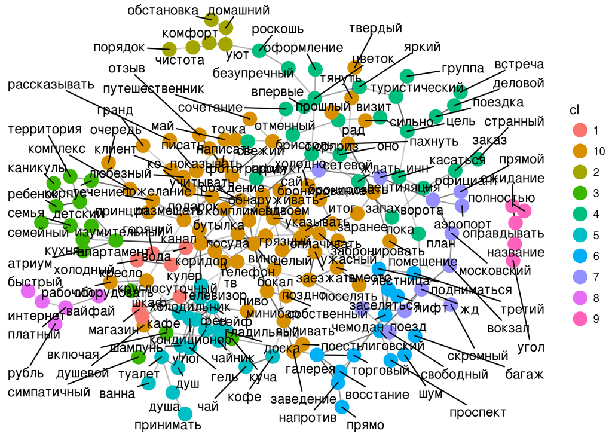

```r
table$V1 = as.character(table$V1)
table$V2 = as.character(table$V2)

pmi_counts_cl = pmi_counts %>%
  filter(pmi > 2) %>%
  left_join(table, by = c("item1" = "V2")) %>%
  dplyr::rename(item1_cl = V1) %>%
  left_join(table, by = c("item2" = "V2")) %>%
  dplyr::rename(item2_cl = V1) %>%
  filter(item1_cl %in% c(1:10) & item2_cl %in% c(1:10))


g = pmi_counts_cl %>%
  dplyr::select(item1, item2,pmi) %>%
  graph_from_data_frame()

V(g)$cl=as.character(table$V1[match(V(g)$name,table$V2)])

ggraph(g, layout = "fr") +
  geom_edge_link(aes(edge_alpha = pmi), show.legend = FALSE) +
  geom_node_point(aes(color = cl), size = 5) +
  geom_node_text(aes(label = name), repel = TRUE) +
  theme_void()
```

**Задание**

1. Выберите три любых кластера в сети, посмотрите, какие слова туда попали, постарайтесь проинтерпретировать получившиеся. Если это сложно сделать, просто посмотрев на слова, посмотрите, в каком контексте они встречаются в отзывах.
2. Постройте сеть с этими кластерами. Обратите внимание на то, какие слова сильнее друг с другом связаны, а также на то, есть ли связи между кластерами.

3*. Посчитайте для слов в этих кластерах G^2 или PMI, которые покажут, насколько эти слова положительные или отрицательные.